# Mixing cover crops suppresses weeds and roto-till improves urban soil compaction and infiltration

Naim Edwards ^a*^

Nicholas Medina <sup>b</sup>

Elizabeth Asker <sup>a</sup>

<sup>a</sup> edwar649@msu.edu, Agriculture and Natural Resources, Michigan State University, 16745 Lamphere St, Detroit, MI, USA 48219; <sup>b</sup> nmedina@umich.edu, Ecology and Evolutionary Biology, University of Michigan, 1105 N University Ave, Ann Arbor, MI, USA

Abstract

Urban soils have been degraded by decades of industrial activities, but they also represent opportunities to improve food sovereignty for urban residents practicing urban agriculture. Urban growers often use varying practices of compost, tillage, and cover cropping, but without distinguishing their benefits to optimize integrated approaches. This study examined how tillage methods representing various intensities and cover crop mixes targeting different functions affected agricultural variables including soil compaction, water infiltration rate, herbaceous weedy plant pressure, and crop yield. Results showed that both roto- and tractor-till significantly affected compaction but not yield compared to no-till, and roto-till also improved infiltration, while tractor-till reached deeper soils but allowed denser weed growth. Mixing sorghum-sudangrass, buckwheat, and cowpea cover crops significantly reduced weed pressure compared to other mixtures, and perennials affected compaction but not soil water infiltration under no-till. These results reveal that medium-intensity tillage may offer more balanced trade-offs for initial management, and that cover crops can help reduce weeds under low-till strategies. Overall this study offers evidence detailing effects of various tillage and cover crop styles that can be of use for smallholder urban growers.

**Keywords**: *urban, compact, weed, till, cover, water*

**Highlights:** - Roto-till improves urban soil compaction and infiltration vs. no-till - Tractor-till improves compaction but not infiltration and also increases weeds - Cover crop mixes suppress weeds - Forage radish yield not affected by till or cover crop mixes - Roto-till and cover crop mixes help improve soils for urban agriculture

***Corresponding author**: Naim Edwards, edwar649@msu.edu

# Introduction

Urban soils have the potential to improve the livelihoods of most of the world *(Acuto et al., 2018)* via implications for climate adaptation, erosion and storm-water runoff management, and local forestry *(Pavao-Zuckerman, 2008)*, but many urban soils are in poor health for cultivation after decades of industrial use, including sealing and structural engineering *(Lal et al., 2015)*. This is especially notable in post-industrial cities of the mid-western USA, where many vacant lots remain on soils can have relatively high compaction, pH, and chemical contamination *(Beniston et al., 2016)*. Degraded urban soils with low organic matter are also likely far from organic carbon saturation *(Stewart et al., 2007)*, making the potential benefit from tailored agricultural management large *(Kumar and Hundal, 2016; Kuzyakov and Zamanian, 2019)*. However, popular single strategies like organic compost amendments to urban gardens, while widely beneficial across many physical, chemical, and biological properties *(Cogger, 2005)*, can also have other side effects like excess phosphorus *(Small et al., 2019)*, which highlights the benefits of new and ongoing research studies of urban soil management, especially of integrated approaches for soil multi-functionality *(Blesh, 2017)* including cover cropping, tillage, diverse mulching, and others. In response to various needs, urban agriculture continues to expand as local communities and non-profit organizations revitalize and establish a diversity of new green initiatives including landscaping to improve local access to healthy food and a cleaner and safer environment *(Block et al., 2012; Clendenning et al., 2016; García-Sempere et al., 2019; Siebert, 2020)*. Urban growers in particular often invest relatively large amounts of money, time, and resources from accessible capital into amending soils for vegetable production *(pers. comms.)*, thereby improving the potential impact of research for promising accessible urban soil remediation strategies, which remains limited beyond compost *(Grossman, 2003)*.

Mechanized tilling has long been a regular strategy improve short-term arability, among others like adding compost, although research studies increasingly report soil degradation after long-term and intensive tillage. Short-term tillage benefits include larger soil pores and lower soil bulk density *(Badalíková, 2010; Hill et al., 1985)*, and potentially more available nutrients *(Wolkowski, 1990)* with less potential weed regeneration *(Barberi and Lo Cascio, 2001; Cordeau et al., 2020)*, making tillage useful against soil compaction and associated water infiltration and drainage issues, which can facilitate faster seeding and crop establishment early in the season *(Monti et al., 2001)*. However, longer-term side effects of excessive and/or very intensive tillage include weaker soil aggregate stability and structure *(Catania et al., 2018; Six et al., 2002)*, increasing dependence on tillage to maintain past yields *(de Cárcer et al., 2019)*, and faster soil erosion *(Richter, 2021)*, which has more recently led to events like the USA Dust Bowl, and historically poses an existential threat to agricultural societies when combined with other stressors *(Amundson et al., 2015; Lal, 2007; Montgomery, 2007)*. In response, sustainable and regenerative agriculture theories promote no-till or minimal-till management approaches like broadfork tools to re-focus on soil health and fertility *(Roger-Estrade et al., 2010; Wang et al., 2006)*, which comes with different challenges like stronger pressure from weeds *(Anderson, 2007)*, highlighting a role for continuing research into diverse no-till strategies. For urban growers, machinery can also be cost-prohibitive, and limited access to agricultural loans *(Daniel, 2007)* has resulted in affected communities adapting by organizing equipment sharing systems, which can be more practical in denser urban housing arrangements compared to diffuse rural ones. This variation in accessibility of machinery can promote mixed tillage strategies by urban growers including tractor- and/or roto-till, which likely have different effects on soil and weed issues, but there remains little public documentation comparing benefits of various tillage styles on remediating urban soils *(Bazzoffi, 1998; Materechera, 2009)*, which slows the innovation of tailored management strategies for the array of urban grower goals.

Cover cropping has been another long-recommended strategy of sustaining longer-term yields by maintaining soil fertility *(Perez, 2021; Richter, 2021)*, although current strategies could be improved from relying on single species to designing complementary species mixes. The namesake benefit of cover crops is to cover the soil in areas without active cultivation, which maintains root activity and weakens erosion *(García-González et al., 2018)*, but different species will also vary in the benefits they can provide based on physiological traits. For example, legumes like cowpea (or black-eyed peas, *Vigna unguiculata subsp. unguiculata*), clovers (*Trifolium sp.*), and hairy vetch (*Vicia villosa*) are popular cover crops because of their additional symbioses with root bacteria that fix nitrogen from the air into soils where it is more available for future crop use *(Grossman et al., 2005)*. Similarly, buckwheat helps scavenge soil phosphorus *(Possinger et al., 2013)*, which is often a limiting macro-nutrient in clay soils *(Mori et al., 2022)*, and could also be combined with compost that is usually high in phosphorus to address recurring soil phosphorus deficiencies. Other plants, including grasses like sorghum (*Sorghum bicolor*), tend to grow deep roots, or have other traits like allelopathic chemical defenses, that compete with weeds enough to keep them suppressed over time *(Weston et al., 1989)*. Broader implications of cover cropping also include higher soil organic matter, though the underlying processes remain complex *(King, 2020)*, and few studies show direct correlations between soil organic matter and yield *(Oldfield et al., 2019)*. Furthermore, while large rural organic farms can benefit from incorporating specifically-chosen cover cropping into their mechanized operations, the reliance of urban agriculture more on labor over machinery offers an opportunity to develop new cover cropping systems that combine seeding and terminating different species together to improve the potential efficiency of soil remediation efforts. For example, sorghum, cowpea, and buckwheat could be combined into a mixed strategy that can increase soil nitrogen, soil phosphorus, and suppress weeds via deep and shallow roots with allelopathic chemical defenses, although cover crop synergisms generally remain understudied *(Bedoussac et al., 2015; Bourke et al., 2021; Mead and Riley, 1981)*. An integrated complex approach to optimizing cover cropping systems including interspecific species interactions are well-posed to be validated by research studies in urban agriculture followed by adaptation to rural agriculture, and even international implications *(Stewart et al., 2013)*.

In this study, we investigated how different tillage techniques and cover crop species mixes affect soil physical properties and yield. Tillage methods ranged from high disturbance using a tractor and implements to minimal disturbance with a broadfork. Cover crop species mixes were selected based on target functions including reducing compaction, suppressing weeds, and perenniality, or potential for sustainable re-growth. We hypothesized that both tillage and cover crop mixing would confer similar benefits to soil functions, which would translate to weed pressure and yield. Accordingly, we predicted that roto-till, a moderate soil disturbance, would best balance compaction and weed pressure benefits, deepening where soil hardpan layers occur that limit root penetration, and thereby increase soil water infiltration rates, and also reduce weed cover, density, and diversity. We also expected that the cover crop mix designed against soil compaction would have the deepest soil harpan depth and highest water infiltration rates compared to other mixes, mostly due to the deeper rooting potential by forage radish (*Raphanus sativus var. longipinnatus*) and ryegrass (*Secale cereale*). Finally we expected that the cover crop mix designed for weed suppression would experience the lowest local weed cover, density, and diversity, due to allelopathic chemical defense traits from buckwheat (*Fagoprum esculentum*) and surghum-sudangrass (*Sorghum bicolor x Sorghum bicolor var. sudanese*).

# Methods

## Site

[figure not shown]

Figure 1: Field site images (a) map data © 2022 USDA-NRCS SSURGO web soil survey showing likely soil class division given field and lab data, (b) soil profile from North-East site area near education center, (c) plot layout design, and (d) aerial drone view of treated study area plots. Photo credits: (b) Naim Edwards, (d) Edgar Cardenas.

## Design

Tillage treatments represented methods of increasing intensity available for small scale agriculture, also varying in cost, machinery needed, and sometimes grower preferences *(Drugova et al., 2022)*. Specifially, treatments included no-till with a broadfork *(NT)*, roto-tiller *(RT)*, and tractor-till *(TT)* with implements. Tractor-till plots were worked with a subsoiler, moldboard plow, and roto-tiller attached to a tractor up to 30.5 cm (1 ft) deep. Roto-till plots were treated with a rototiller implement up to 20 cm (7.9 in) deep. Lastly, no-till plots were worked with only a broadfork up to 10 cm (3.9 in) deep. All tilling was done once early in the season after compost application.

## Sampling

Soil compaction was measured with a penetrometer *(AgraTronix #08180)* in four randomly selected spots within each quarter of every plot, as the depth where resistance was 2 MPa (290.1 psi, *lbs in<sup>-2</sup>*), which is considered hardpan that roots typically cannot penetrate *(Correa et al., 2019)*. Measurements were recorded to the nearest *2.5 cm (1 inch)* on dry days in July and October 2019.

Soil water infiltration down to 11.1 cm *(8.75 in)* depth was measured using a 16.5 *(9.5 in)* wide aluminum cylinder, and recording the time up to 160 sec for *1 L (32 fl oz)* to pass through, which represented a typical rainfall amount onto ~0.10 *m<sup>2</sup>* (~1 *ft<sup>2</sup>*) of soil area (waterdata.usgs.gov).

Weed pressure was measured using percent cover, richness, and density. Weed cover was estimated as the total proportion of plot area covered by any weeds, using a scale of 1-10 with one indicating **only one species / near zero stems** observed to 10 being **10 species present / almost the entire plot surface covered at some level with at least part of a weed plant (e.g. stem or leaf)**. Weed richness was measured as in other studies *(Storkey and Neve, 2018)* as a unique count of morphospecies observed in each plot. Weed density was measured as the number of individual stems of either of the two most abundant weed species – pigweed (*Amaranthus viridis*) and velvetleaf (*Abutilon theophrasti*) – using a discrete scale in increments of 10 with zero indicating neither species present and five indicating 50 or more total individuals stems of either species.

Five forage radish (Brassica *Raphanus sativus var. longipinnatus*) roots were randomly selected from each plot in the compaction treatment and measured for length, individually, and wet weight, as a cluster. The length of a radish root was measured from the hypocotyl, or root cap, to where the root became ~6.3 mm (~1⁄4 in) wide.

## Statistics

Field space limited strict plot replication for combined treatments (*n*=3), and thus inference from advanced nested mixed models *(Silk et al., 2020)*, so analysis focused on specific hypotheses tested using simpler, more conservative non-parametric tests that make few underlying assumptions about data and thus appropriate for data with lower replication. Kruskal-Wallis tests were run for tillage and cover crop treatments separately, with alpha corrections from 0.05 to 0.01 under multiple comparisons to descriptively parse any treatment interactions, and overall significant treatment effects were followed up by post-hoc Wilcoxon pairwise tests with Holm-corrected p-value adjustments. All data were centered at plot-level medians, and where applicable pooled across sampling times given no preliminary significant variation along this axis, together with minimal relevance to focal hypotheses in field studies *(Davies and Gray, 2015)*, and was a general solution to uneven sampling across response variables, minimally increasing statistical power (base *n* > 3-6). For clarity, results figures were designed to reflect statistical models and grouping transparently. Significant treatment effect sizes were estimated with *eta<sup>2</sup>* *(Tomczak and Tomczak, 2014)* and simpler raw median differences at finer pairwise levels. All calculations and analyzes were done in R version 4.2.0 (2022-04-22) *(R Core Team, 2022)* with useful functions from the packages *tidyverse* 1.3.1 *(Wickham et al., 2019)*, *rstatix* 0.7.0 and *ggpubr* 0.4.0 *(Kassambara, 2021)*. Data and code are stored at nmedina17.github.com/must, documented using R packages *here* *(Müller, 2020)*, *bookdown* *(Xie, 2022a)*, *measurements* *(Birk, 2019)*, *taxize* *(Chamberlain et al., 2020)*, *knitr* *(Xie, 2022b)*, and *rmarkdown* *(Allaire et al., 2022)*.

# Results

## Compaction

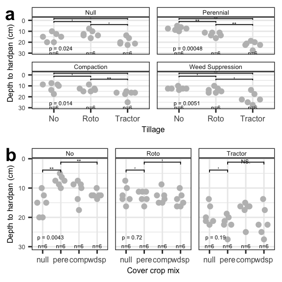

Compaction was not affected by cover crops among tillage groups overall ( *H* = 2, *df* = 3, *n* = 72, *p* = 0.57 ), but was significantly affected by cover crops specifically under no-till conditions ( *df = 3*, *n = 6*, *p<sub>adj</sub> = <0.01* ) (Fig 2b). Under no-till, the perennial mix had significantly shallower depth to hardpan compared to both null ( *p<sub>adj</sub> = <0.01* ) and weed suppression mixes ( *p<sub>adj</sub> = <0.01* ), raising the depth to hardpan by ~*5* cm ( 2, or ~*30-100*% ) compared to each mix, up to ~12.5 ± 7.4 cm ( 4.9 ± 2.9 in ) below the soil surface (Fig 2b).

## Infiltration

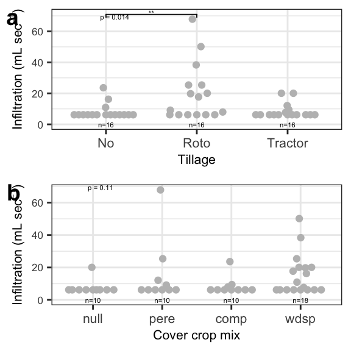

## Weed pressure

Weed density was overall marginally significantly affected by tillage ( *H* = 6.5, *df* = 2, *n* = 72, *p* = 0.039 ) by ~25.1 %, although weed cover ( *H* = 0.2, *df* = 2, *n* = 36, *p* = 0.92 ) and richness ( *H* = 1.6, *df* = 2, *n* = 72, *p* = 0.44 ) were not (Fig 4a). Weeds under tractor-till were marginally significantly denser compared to no-till ( *p<sub>adj</sub>* = 0.1 ) and roto-till ( *p<sub>adj</sub>* = 0.1 ), denser by ~6.5 % compared to each tillage group, up to ~ 0.8 ± 0.2 *stems per m<sup>-2</sup>* .

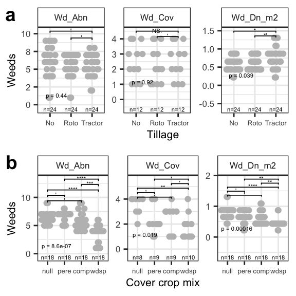

## Yield

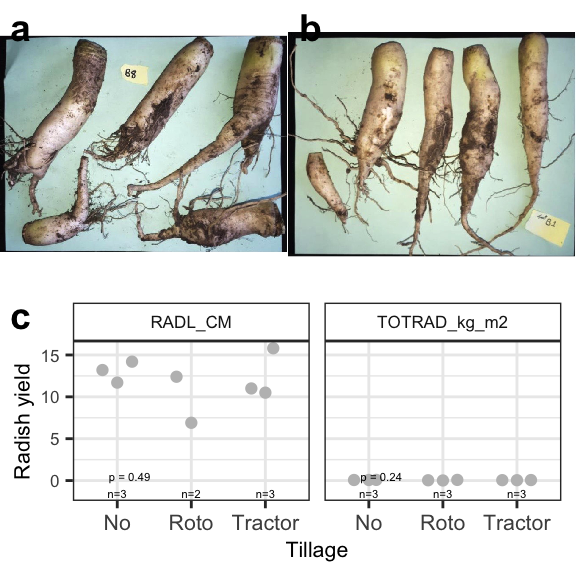

Figure 5: Yield data (a) from no-till and (b) tractor-till. Photo credits: Naim Edwards.

# Discussion

Overall this study informs urban soil management by supporting the use of tillage to address compaction issues and improve infiltration, together with cover crops to also reduce weed pressure. Our hypothesis was partially supported, because overall tillage significantly deepened the depth to hardpan by ~0.5 (Fig 2a), which was within the range of effect sizes measured among the various cover crop mixes within the no-till treatment (Fig 2b). Additionally, infiltration was significantly affected by tillage, with roto-till showing the fastest rates (Fig 3a), which agreed with our predictions. Furthermore, weed pressure was significantly affected by both cover crop mixes and tillage (Fig 4), although effects from cover crop mixes, especially the weed suppression mix, were more widespread among multiple measured variables (Fig 4b). Despite these significant effects on soils, infiltration, and weeds, yields did not respond to tillage treatments.

Water infiltration is a key function to improve urban soil functioning for agriculture by minimizing erosion and improving root available water, as well as mitigating storm-water runoff and potentially contaminated flooding *(Masoner et al., 2019)* that often occurs after short heavy rains, due to soil sealing by concrete near hillslopes *(Dreelin et al., 2006)*. This study found that roto-till resulted in significantly faster infiltration compared to no-till, unlike tractor-till, suggesting that roto-till management can generally be effective for improving infiltration and drainage. This result could be explained by medium intensity roto-till increasing soil macro-porosity, which compared to soil micro-pores bind water less tightly allowing to flow faster *(Gerke, 2006)*. In contrast, the tractor diffused tillage energy across deeper soil volume, lowering the density of any added soil macro-pores and thereby making it easier for soil particles to settle back together, whereas no-till may have needed more time to improve macro-porosity via organic matter effects on soil structure *(King, 2020)*. It is also possible that this result could be explained by compost incorporation, where tractor-till similarly incorporated compost more diffusely throughout the soil profile, diluting any compost benefits to infiltration. Against a one inch rain event, this study supported the use of roto-till, but not no-till or tractor-till, which showed rates of only ~ 6.2 ± 0 mL per sec ( 0.1 ± 0 gal per min ), which would likely result in runoff pooling in roads and soil erosion. Regarding cover crops, this study suggests that perennials may not have notable significant effects on infiltration rates, despite detectable effects on compaction. Based on these findings, roto-till together with compost may be an effective strategy to improve urban soil water infiltration in the short-term, even if no-till may appear to have more evidence as a longer-term strategy *(Cusser et al., 2020)*.

Despite overall significant effects by tillage on compaction, infiltration, and weeds, tillage did not significantly affect radish yield. As is, this study does not rule out more complex relationships between soil compaction, infiltration, and crop yield, as suggested by emerging ideas *(Ryan et al., 2007; Vandermeer and Perfecto, 2017)*. However, with further replication, it is possible that no-till would show slightly higher yields, validating some similar studies *(Nunes et al., 2018)*. Overall yields can respond more to longer-term reservoirs of water and nutrients like mulched compost compared to shorter-term, transient influxes brought by infiltration processes *(Schlegel et al., 2015; Schlegel and Havlin, 1995)*. As a result, it is possible that similar alternative soil management practices like no-till combined with compost and mulching application may lead to better yields, although the translation of no-till benefits to soil structure *(Du et al., 2015; Sheehy et al., 2015)* on yield are not guaranteed *(Martínez et al., 2016)* nor do they appear to be widespread *(Pittelkow et al., 2015; VandenBygaart, 2016)*. Additionally, other studies suggest that forage radish can be an effective cover crop in reducing compaction and building soil structure, with minimal or no mechanical tillage *(Chen and Weil, 2010; Lawley et al., 2011)*. However ultimately this study suggests the need for future studies of processes tying yield to land management strategies particularly in similar urban clay soils with legacy compaction and pH concerns under smallholder management and possibly including occassional tillage *(Blanco-Canqui and Wortmann, 2020; Ekboir, 2001)*.

Taken together, this study presents data that, in addition to validating previous studies supporting general tillage for short-term soil fertility, also supports the partial use of medium-intensity roto-till and cover crop mixtures *(Chapagain et al., 2020)* specifically for weed suppression. This study serves as a model demonstration of both widely accessible and effective strategies for growing on re-purposed urban soils after urban land-use turnover. We advocate for the maximal use of cover crop mixes for various target functions, with medium-intensity tillage to jump-start urban cultivation.

# Acknowledgements

Thanks to previous anonymous reviewers, and peer student (Kristel, Zach,) discussion of initial drafts.

# Funding

*This research did not receive any specific grant from funding agencies in the public, commercial, or not-for-profit sectors.*

# Declaration of interests

Authors declare no conflicts of interest.

# Data statement

Data and code available at nmedina17.github.com/must.

# References

Acuto, M., Parnell, S., Seto, K.C., 2018. Building a global urban science. Nature Sustainability 1, 2–4. https://doi.org/10.1038/s41893-017-0013-9

Allaire, J., Xie, Y., McPherson, J., Luraschi, J., Ushey, K., Atkins, A., Wickham, H., Cheng, J., Chang, W., Iannone, R., 2022. [Rmarkdown: Dynamic documents for r](https://github.com/rstudio/rmarkdown).

Amundson, R., Berhe, A.A., Hopmans, J.W., Olson, C., Sztein, A.E., Sparks, D.L., 2015. Soil science. Soil and human security in the 21st century. Science (New York, N.Y.) 348, 1261071. https://doi.org/10.1126/science.1261071

Anderson, R.L., 2007. Managing weeds with a dualistic approach of prevention and control. A review. Agronomy for Sustainable Development 27, 13–18. https://doi.org/10.1051/agro:2006027

Badalíková, B., 2010. Influence of Soil Tillage on Soil Compaction, in: Dedousis, A.P., Bartzanas, T. (Eds.), Soil Engineering. Springer Berlin Heidelberg, Berlin, Heidelberg, pp. 19–30. https://doi.org/10.1007/978-3-642-03681-1_2

Barberi, P., Lo Cascio, B., 2001. Long-term tillage and crop rotation effects on weed seedbank size and composition. Weed Research 41, 325–340. https://doi.org/10.1046/j.1365-3180.2001.00241.x

Bàrberi, P., Bocci, G., Carlesi, S., Armengot, L., Blanco-Moreno, J.M., Sans, F.X., 2018. Linking species traits to agroecosystem services: A functional analysis of weed communities. Weed Research 58, 76–88. https://doi.org/10.1111/wre.12283

Bazzoffi, P., 1998. The effect of urban refuse compost and different tractors tyres on soil physical properties, soil erosion and maize yield. Soil and Tillage Research 48, 275–286. https://doi.org/10.1016/S0167-1987(98)00133-0

Bedoussac, L., Journet, E.-P., Hauggaard-Nielsen, H., Naudin, C., Corre-Hellou, G., Jensen, E.S., Prieur, L., Justes, E., 2015. Ecological principles underlying the increase of productivity achieved by cereal-grain legume intercrops in organic farming. A review. Agronomy for Sustainable Development 35, 911–935. https://doi.org/10.1007/s13593-014-0277-7

Beniston, J.W., Lal, R., Mercer, K.L., 2016. Assessing and Managing Soil Quality for Urban Agriculture in a Degraded Vacant Lot Soil: ASSESSING AND MANAGING SOIL QUALITY FOR URBAN AGRICULTURE. Land Degradation & Development 27, 996–1006. https://doi.org/10.1002/ldr.2342

Birk, M.A., 2019. [Measurements: Tools for units of measurement](https://CRAN.R-project.org/package=measurements).

Blanco-Canqui, H., Wortmann, C.S., 2020. Does occasional tillage undo the ecosystem services gained with no-till? A review. Soil and Tillage Research 198, 104534. https://doi.org/10.1016/j.still.2019.104534

Blesh, J., 2017. Functional traits in cover crop mixtures: Biological nitrogen fixation and multifunctionality. Journal of Applied Ecology 55, 38–48. https://doi.org/10.1111/1365-2664.13011

Block, D.R., Chávez, N., Allen, E., Ramirez, D., 2012. Food sovereignty, urban food access, and food activism: Contemplating the connections through examples from Chicago. Agriculture and Human Values 29, 203–215. https://doi.org/10.1007/s10460-011-9336-8

Bourke, P.M., Evers, J.B., Bijma, P., van Apeldoorn, D.F., Smulders, M.J.M., Kuyper, T.W., Mommer, L., Bonnema, G., 2021. Breeding Beyond Monoculture: Putting the “Intercrop” Into Crops. Frontiers in Plant Science 12, 734167. https://doi.org/10.3389/fpls.2021.734167

Catania, P., Badalucco, L., Laudicina, V.A., Vallone, M., 2018. Effects of tilling methods on soil penetration resistance, organic carbon and water stable aggregates in a vineyard of semiarid Mediterranean environment. Environmental Earth Sciences 77, 348. https://doi.org/10.1007/s12665-018-7520-5

Chamberlain, S., Szoecs, E., Foster, Z., Arendsee, Z., Boettiger, C., Ram, K., Bartomeus, I., Baumgartner, J., O’Donnell, J., Oksanen, J., Tzovaras, B.G., Marchand, P., Tran, V., Salmon, M., Li, G., Grenié, M., 2020. [Taxize: Taxonomic information from around the web](https://github.com/ropensci/taxize).

Chapagain, T., Lee, E.A., Raizada, M.N., 2020. The Potential of Multi-Species Mixtures to Diversify Cover Crop Benefits. Sustainability 12, 2058. https://doi.org/10.3390/su12052058

Chen, G., Weil, R.R., 2010. Penetration of cover crop roots through compacted soils. Plant and Soil 331, 31–43. https://doi.org/10.1007/s11104-009-0223-7

Clark, A. (Ed.), 2007. Managing cover crops profitably, 3rd ed. ed, Handbook series. Sustainable Agriculture Research & Education (SARE), College Park, MD.

Clendenning, J., Dressler, W.H., Richards, C., 2016. Food justice or food sovereignty? Understanding the rise of urban food movements in the USA. Agriculture and Human Values 33, 165–177. https://doi.org/10.1007/s10460-015-9625-8

Cogger, C.G., 2005. Potential Compost Benefits for Restoration Of Soils Disturbed by Urban Development. Compost Science & Utilization 13, 243–251. https://doi.org/10.1080/1065657X.2005.10702248

Cordeau, S., Baudron, A., Adeux, G., 2020. Is Tillage a Suitable Option for Weed Management in Conservation Agriculture? Agronomy 10, 1746. https://doi.org/10.3390/agronomy10111746

Correa, J., Postma, J.A., Watt, M., Wojciechowski, T., 2019. Soil compaction and the architectural plasticity of root systems. Journal of Experimental Botany 70, 6019–6034. https://doi.org/10.1093/jxb/erz383

Cusser, S., Bahlai, C., Swinton, S.M., Robertson, G.P., Haddad, N.M., 2020. Long-term research avoids spurious and misleading trends in sustainability attributes of no-till. Global Change Biology 26, 3715–3725. https://doi.org/10.1111/gcb.15080

Daniel, P., 2007. African American Farmers and Civil Rights 37.

Davies, G.M., Gray, A., 2015. Don’t let spurious accusations of pseudoreplication limit our ability to learn from natural experiments (and other messy kinds of ecological monitoring). Ecology and Evolution 5, 5295–5304. https://doi.org/10.1002/ece3.1782

de Cárcer, P.S., Sinaj, S., Santonja, M., Fossati, D., Jeangros, B., 2019. Long-term effects of crop succession, soil tillage and climate on wheat yield and soil properties. Soil and Tillage Research 190, 209–219. https://doi.org/10.1016/j.still.2019.01.012

Douglas, J.T., Koppi, A.J., Moran, C.J., 1992. Alteration of the structural attributes of a compact clay loam soil by growth of a perennial grass crop. Plant and Soil 139, 195–202. https://doi.org/10.1007/BF00009310

Dreelin, E.A., Fowler, L., Ronald Carroll, C., 2006. A test of porous pavement effectiveness on clay soils during natural storm events. Water Research 40, 799–805. https://doi.org/10.1016/j.watres.2005.12.002

Drugova, T., Curtis, K.R., Ward, R.A., 2022. Producer preferences for drought management strategies in the arid west. Renewable Agriculture and Food Systems 37, 14–23. https://doi.org/10.1017/S1742170521000259

Du, Z., Ren, T., Hu, C., Zhang, Q., 2015. Transition from intensive tillage to no-till enhances carbon sequestration in microaggregates of surface soil in the North China Plain. Soil and Tillage Research 146, 26–31. https://doi.org/10.1016/j.still.2014.08.012

Ekboir, J., 2001. Developing No-Till Packages for Small-Scale Farmers.

FAO, 2014. World reference base for soil resources 2014: International soil classification system for naming soils and creating legends for soil maps. FAO, Rome.

García-González, I., Hontoria, C., Gabriel, J.L., Alonso-Ayuso, M., Quemada, M., 2018. Cover crops to mitigate soil degradation and enhance soil functionality in irrigated land. Geoderma 322, 81–88. https://doi.org/10.1016/j.geoderma.2018.02.024

García-Sempere, A., Morales, H., Hidalgo, M., Ferguson, B.G., Rosset, P., Nazar-Beutelspacher, A., 2019. Food Sovereignty in the city?: A methodological proposal for evaluating food sovereignty in urban settings. Agroecology and Sustainable Food Systems 43, 1145–1173. https://doi.org/10.1080/21683565.2019.1578719

Gerke, H.H., 2006. Preferential flow descriptions for structured soils. Journal of Plant Nutrition and Soil Science 169, 382–400. https://doi.org/10.1002/jpln.200521955

Grossman, J.M., 2003. Exploring farmer knowledge of soil processes in organic coffee systems of Chiapas, Mexico. Geoderma 111, 267–287. https://doi.org/10.1016/S0016-7061(02)00268-9

Grossman, J.M., Sheaffer, C., Wyse, D., Graham, P.H., 2005. Characterization of slow-growing root nodule bacteria from Inga oerstediana in organic coffee agroecosystems in Chiapas, Mexico. Applied Soil Ecology 29, 236–251. https://doi.org/10.1016/j.apsoil.2004.12.008

Hesse, E., Rees, M., Müller-Schärer, H., 2007. Seed bank persistence of clonal weeds in contrasting habitats: Implications for control. Plant Ecology 190, 233–243. https://doi.org/10.1007/s11258-006-9203-7

Hill, R.L., Horton, R., Cruse, R.M., 1985. Tillage Effects on Soil Water Retention and Pore Size Distribution of Two Mollisols. Soil Science Society of America Journal 49, 1264–1270. https://doi.org/10.2136/sssaj1985.03615995004900050039x

Hoogmoed, W.B., Bouma, J., 1980. A Simulation Model for Predicting Infiltration into Cracked Clay Soil. Soil Science Society of America Journal 44, 458–461. https://doi.org/10.2136/sssaj1980.03615995004400030003x

Kassambara, A., 2021. [Rstatix: Pipe-friendly framework for basic statistical tests](https://CRAN.R-project.org/package=rstatix).

Katz, D.S.W., Carey, T.S., 2014. Heterogeneity in ragweed pollen exposure is determined by plant composition at small spatial scales. Science of the Total Environment 485–486, 435–440. https://doi.org/10.1016/j.scitotenv.2014.03.099

King, A.E., 2020. Soil Organic Matter as Catalyst of Crop Resource Capture. Frontiers in Environmental Science 8, 8.

Krause, M.A., Black, J.R., 1995. Optimal Adoption Strategies for No-till Technology in Michigan. Review of Agricultural Economics 17, 299. https://doi.org/10.2307/1349575

Kumar, K., Hundal, L.S., 2016. Soil in the City: Sustainably Improving Urban Soils. Journal of Environmental Quality 45, 2–8. https://doi.org/10.2134/jeq2015.11.0589

Kuzyakov, Y., Zamanian, K., 2019. Reviews and syntheses: Agropedogenesis humankind as the sixth soil-forming factor and attractors of agricultural soil degradation. Biogeosciences 16, 4783–4803. https://doi.org/10.5194/bg-16-4783-2019

Lal, R., 2007. Soil Science and the Carbon Civilization 71, 1425–1437. https://doi.org/10.2136/sssaj2007.0001

Lal, R., Negassa, W., Lorenz, K., 2015. Carbon sequestration in soil. Current Opinion in Environmental Sustainability 15, 79–86. https://doi.org/10.1016/j.cosust.2015.09.002

Lawley, Y.E., Weil, R.R., Teasdale, J.R., 2011. Forage Radish Cover Crop Suppresses Winter Annual Weeds in Fall and Before Corn Planting. Agronomy Journal 103, 137–144. https://doi.org/10.2134/agronj2010.0187

Liu, J.G., Mahoney, K.J., Sikkema, P.H., Swanton, C.J., 2009. The importance of light quality in crop-weed competition: Light quality and crop competition. Weed Research 49, 217–224. https://doi.org/10.1111/j.1365-3180.2008.00687.x

Martínez, I., Chervet, A., Weisskopf, P., Sturny, W.G., Etana, A., Stettler, M., Forkman, J., Keller, T., 2016. Two decades of no-till in the Oberacker long-term field experiment: Part I. Crop yield, soil organic carbon and nutrient distribution in the soil profile. Soil and Tillage Research 163, 141–151. https://doi.org/10.1016/j.still.2016.05.021

Martins, L.M.V., Xavier, G.R., Rangel, F.W., Ribeiro, J.R.A., Neves, M.C.P., Morgado, L.B., Rumjanek, N.G., 2003. Contribution of biological nitrogen fixation to cowpea: A strategy for improving grain yield in the semi-arid region of Brazil. Biology and Fertility of Soils 38, 333–339. https://doi.org/10.1007/s00374-003-0668-4

Masoner, J.R., Kolpin, D.W., Cozzarelli, I.M., Barber, L.B., Burden, D.S., Foreman, W.T., Forshay, K.J., Furlong, E.T., Groves, J.F., Hladik, M.L., Hopton, M.E., Jaeschke, J.B., Keefe, S.H., Krabbenhoft, D.P., Lowrance, R., Romanok, K.M., Rus, D.L., Selbig, W.R., Williams, B.H., Bradley, P.M., 2019. Urban Stormwater: An Overlooked Pathway of Extensive Mixed Contaminants to Surface and Groundwaters in the United States. Environmental Science & Technology 53, 10070–10081. https://doi.org/10.1021/acs.est.9b02867

Materechera, S.A., 2009. Tillage and tractor traffic effects on soil compaction in horticultural fields used for peri-urban agriculture in a semi-arid environment of the North West Province, South Africa. Soil and Tillage Research 103, 11–15. https://doi.org/10.1016/j.still.2008.09.001

Mead, R., Riley, J., 1981. A Review of Statistical Ideas Relevant to Intercropping Research. Journal of the Royal Statistical Society. Series A (General) 144, 462. https://doi.org/10.2307/2981827

Montgomery, D.R., 2007. Soil erosion and agricultural sustainability 104, 13268–13272.

Monti, A., Venturi, P., Elbersen, H.W., 2001. Evaluation of the establishment of lowland and upland switchgrass (Panicum virgatum L.) Varieties under different tillage and seedbed conditions in northern Italy. Soil and Tillage Research 63, 75–83. https://doi.org/10.1016/S0167-1987(01)00238-0

Mori, T., Wang, S., Zhang, W., Mo, J., 2022. Microbial assembly adapted to low-P soils in three subtropical forests by increasing the maximum rate of substrate conversion of acid phosphatases but not by decreasing the half-saturation constant. European Journal of Soil Biology 108, 103377. https://doi.org/10.1016/j.ejsobi.2021.103377

Müller, K., 2020. [Here: A simpler way to find your files](https://CRAN.R-project.org/package=here).

Nunes, M.R., van Es, H.M., Schindelbeck, R., Ristow, A.J., Ryan, M., 2018. No-till and cropping system diversification improve soil health and crop yield. Geoderma 328, 30–43. https://doi.org/10.1016/j.geoderma.2018.04.031

Oldfield, E.E., Bradford, M.A., Wood, S.A., 2019. Global meta-analysis of the relationship between soil organic matter and crop yields 15–32.

Ozpinar, S., Cay, A., 2006. Effect of different tillage systems on the quality and crop productivity of a clayloam soil in semi-arid north-western Turkey. Soil and Tillage Research 88, 95–106. https://doi.org/10.1016/j.still.2005.04.009

Pavao-Zuckerman, M.A., 2008. The Nature of Urban Soils and Their Role in Ecological Restoration in Cities. Restoration Ecology 16, 642–649. https://doi.org/10.1111/j.1526-100X.2008.00486.x

Perez, R., 2021. Freedom Farmers: Agricultural Resistance and the Black Freedom Movement, by Monica M.White, Chapel Hill: University of North Carolina Press, 2018. 208 pp. $14.99 (e-book). ISBN: 978-1-4696-4370-0. Rural Sociology 86, 974–977. https://doi.org/10.1111/ruso.12423

Pittelkow, C.M., Linquist, B.A., Lundy, M.E., Liang, X., van Groenigen, K.J., Lee, J., van Gestel, N., Six, J., Venterea, R.T., van Kessel, C., 2015. When does no-till yield more? A global meta-analysis. Field Crops Research 183, 156–168. https://doi.org/10.1016/j.fcr.2015.07.020

Possinger, A.R., Byrne, L.B., Breen, N.E., 2013. Effect of buckwheat ( *Fagopyrum* *Esculentum* ) on soil-phosphorus availability and organic acids. Journal of Plant Nutrition and Soil Science 176, 16–18. https://doi.org/10.1002/jpln.201200337

R Core Team, 2022. [R: A language and environment for statistical computing](https://www.R-project.org/). R Foundation for Statistical Computing, Vienna, Austria.

Richter, D.D., 2021. Searching for solutions to our soil woes–A World Without Soil: The Past, Present, and Precarious Future of the Earth Beneath Our Feet, Jo Handelsman, Yale University Press, 2021, 272 pp. Science 374, 1452–1452. https://doi.org/10.1126/science.abm4765

Roger-Estrade, J., Anger, C., Bertrand, M., Richard, G., 2010. Tillage and soil ecology: Partners for sustainable agriculture. Soil and Tillage Research 111, 33–40. https://doi.org/10.1016/j.still.2010.08.010

Ryan, J.G., Ludwig, J.A., Mcalpine, C.A., 2007. Complex adaptive landscapes (CAL): A conceptual framework of multi-functional, non-linear ecohydrological feedback systems. Ecological Complexity 4, 113–127. https://doi.org/10.1016/j.ecocom.2007.03.004

Salem, H.M., Valero, C., Muñoz, M.Á., Rodríguez, M.G., Silva, L.L., 2015. Short-term effects of four tillage practices on soil physical properties, soil water potential, and maize yield. Geoderma 237–238, 60–70. https://doi.org/10.1016/j.geoderma.2014.08.014

Sanginga, N., Lyasse, O., Singh, B.B., 2000. Phosphorus use efficiency and nitrogen balance of cowpea breeding lines in a low P soil of the derived savanna zone in West Africa. Plant and Soil 10.

Schlegel, A.J., Assefa, Y., Bond, H.D., Wetter, S.M., Stone, L.R., 2015. Soil Physicochemical Properties after 10 Years of Animal Waste Application. Soil Science Society of America Journal 79, 711–719. https://doi.org/10.2136/sssaj2014.11.0461

Schlegel, A.J., Havlin, J.L., 1995. Corn Response to Long-Term Nitrogen and Phosphorus Fertilization. Journal of Production Agriculture 8, 181–185. https://doi.org/10.2134/jpa1995.0181

Sheehy, J., Regina, K., Alakukku, L., Six, J., 2015. Impact of no-till and reduced tillage on aggregation and aggregate-associated carbon in Northern European agroecosystems. Soil and Tillage Research 150, 107–113. https://doi.org/10.1016/j.still.2015.01.015

Siebert, A., 2020. Transforming urban food systems in South Africa: Unfolding food sovereignty in the city. The Journal of Peasant Studies 47, 401–419. https://doi.org/10.1080/03066150.2018.1543275

Silk, M.J., Harrison, X.A., Hodgson, D.J., 2020. Perils and pitfalls of mixed-effects regression models in biology. PeerJ 8, e9522. https://doi.org/10.7717/peerj.9522

Six, J., Feller, C., Denef, K., Ogle, S., De Moraes, J.C., Albrecht, A., 2002. Soil organic matter, biota and aggregation in temperate and tropical soils - Effects of no-tillage. https://doi.org/10.1051/agro

Small, G., Shrestha, P., Metson, G.S., Polsky, K., Jimenez, I., Kay, A., 2019. Excess phosphorus from compost applications in urban gardens creates potential pollution hotspots Excess phosphorus from compost applications in urban gardens creates potential pollution hotspots.

Smith, A.P., Marín-Spiotta, E., Balser, T., 2015. Successional and seasonal variations in soil and litter microbial community structure and function during tropical postagricultural forest regeneration: A multiyear study. Global Change Biology 21, 3532–3547. https://doi.org/10.1111/gcb.12947

Stewart, C.E., Paustian, K., Conant, R.T., Plante, A.F., Six, J., 2007. Soil carbon saturation: Concept, evidence and evaluation. Biogeochemistry 86, 19–31. https://doi.org/10.1007/s10533-007-9140-0

Stewart, R., Korth, M., Langer, L., Rafferty, S., Da Silva, N.R., van Rooyen, C., 2013. What are the impacts of urban agriculture programs on food security in low and middle-income countries? Environmental Evidence 2, 7. https://doi.org/10.1186/2047-2382-2-7

Storkey, J., Neve, P., 2018. What good is weed diversity? Weed Research 58, 239–243. https://doi.org/10.1111/wre.12310

Tomczak, M., Tomczak, E., 2014. The need to report effect size estimates revisited. An overview of some recommended measures of effect size 1, 7.

VandenBygaart, A.J., 2016. The myth that no-till can mitigate global climate change. Agriculture, Ecosystems & Environment 216, 98–99. https://doi.org/10.1016/j.agee.2015.09.013

Vandermeer, J., Perfecto, I., 2017. Ecological complexity and agroecosystems : Seven themes from theory. Agroecology and Sustainable Food Systems 41, 697–722. https://doi.org/10.1080/21683565.2017.1322166

Wang, X.-B., Cai, D.-X., Hoogmoed, W.B., Oenema, O., Perdok, U.D., 2006. Potential Effect of Conservation Tillage on Sustainable Land Use: A Review of Global Long-Term Studies. Pedosphere 16, 587–595. https://doi.org/10.1016/S1002-0160(06)60092-1

Weston, L.A., Harmon, R., Mueller, S., 1989. Allelopathic potential of sorghum-sudangrass hybrid (sudex). Journal of Chemical Ecology 15, 1855–1865. https://doi.org/10.1007/BF01012272

Wickham, H., Averick, M., Bryan, J., Chang, W., McGowan, L.D., François, R., Grolemund, G., Hayes, A., Henry, L., Hester, J., Kuhn, M., Pedersen, T.L., Miller, E., Bache, S.M., Müller, K., Ooms, J., Robinson, D., Seidel, D.P., Spinu, V., Takahashi, K., Vaughan, D., Wilke, C., Woo, K., Yutani, H., 2019. Welcome to the tidyverse. Journal of Open Source Software 4, 1686. https://doi.org/10.21105/joss.01686

Wolkowski, R.P., 1990. Relationship between Wheel-Traffic-Induced Soil Compaction, Nutrient Availability, and Crop Growth: A Review. Journal of Production Agriculture 3, 460–469. https://doi.org/10.2134/jpa1990.0460

Xie, Y., 2022a. [Bookdown: Authoring books and technical documents with r markdown](https://github.com/rstudio/bookdown).

Xie, Y., 2022b. [Knitr: A general-purpose package for dynamic report generation in r](https://yihui.org/knitr/).

Zhu, Y.G., He, Y.Q., Smith, S.E., Smith, F.A., 2002. Buckwheat (Fagopyrum esculentum Moench) has high capacity to take up phosphorus (P) from a calcium (Ca)-bound source. Plant and Soil 239, 1–8. https://doi.org/10.1023/A:1014958029905